# STAT 428: Homework 6: Chapter 8 and 9 and Optimization

YONG CHEN yongc2

Due Week 14 Saturday, December 1 by 11.59 PM on Compass

## Exercise 1

**Maximum Likelihood Estimator** In the exercise parts that follow, you must show derivation by hand(typed up in latex from within RMarkdown), include code and plots where appropriate. Also, do compare your results from code with those you got by hand.

Suppose that $X$ is a discrete random variable with

- $\mathbb{P}(X= 0) = \displaystyle\frac{1}{4} \theta$;
- $\mathbb{P}(X= 1) = \displaystyle\frac{3}{4} \theta$;
- $\mathbb{P}(X= 2) = \displaystyle\frac{1}{4} (1-\theta)$;
- $\mathbb{P}(X= 3) = \displaystyle\frac{3}{4} (1-\theta)$;

where $0 \le \theta \le 1$ is a parameter. The following 10 independent observations were taken from such a distribution: $(3,0,2,1,3,2,1,0,2,1)$.

**(a)** What is the likelihood function $L(\theta$) for the sample $(3,0,2,1,3,2,1,0,2,1)$?  
$\frac{3^5}{4^{10}} \theta^{5} (1-\theta)^5$

**(b)** What is the log-likelihood function$l(\theta$) for the sample $(3,0,2,1,3,2,1,0,2,1)$?  
$log \frac{3^5}{4^{10}}+5log\theta+5log(1-\theta)$

**(c)** What is the maximum log-likelihood estimate of $\theta$? *(Hint: Recall the `optimize` function in R.)*

$\frac{dl(\theta)}{d\theta}=\frac{5}{\theta}-\frac{5}{1-{\theta}}=0$

$\hat{\theta}=0.5$

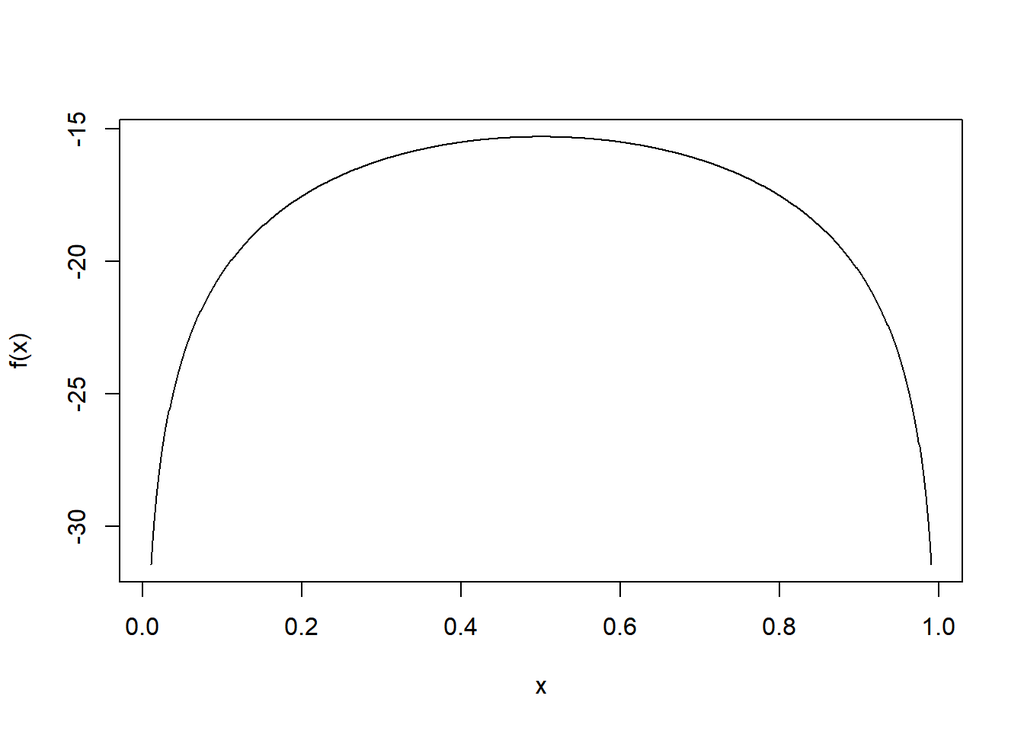

```r
f=function(x){log(3^5/4^10)+5*log(x)+5*log(1-x)}
x=seq(0.01,0.99,length=1000)
plot(x,f(x),type="l")
```

```r
optimize(f,lower=0,upper=1,maximum = TRUE)
```

```
## $maximum
## [1] 0.5
##
## $objective
## [1] -15.3
```

## Exercise 2

**Maximum Likelihood Estimator in Logistic Regression** Suppose we have data in pairs $(x_{i},y_{i})$ for $i=1,2,...,25$. Conditional on $x_{i}$, $y_{i}$ is Bernoulli with success probability

$$p_{i}=P[y_{i}=1|x_{i}]=exp(\beta_{0}+\beta_{1}x_{i})/(1+exp(\beta_{0}+\beta_{1}x_{i}))$$

The aim is to compute the maximum likelihood estimate $\hat{{\bf{\beta}}}$ of the parameter vector ${\bf{\beta}}=(\beta_{0},\beta_{1})^{T}$.

The log-likelihood is

$$\ell({\bf{\beta}})=\sum_{i=1}^{n}[y_{i}log(p_{i})+(1-y_{i})log(1-p_{i})]$$

**(a)** Use the function `optim()`to compute $\hat{{\bf{\beta}}}$ using initial value (.25,.75).

```r
x = c(1.34, -1.38, -0.19, -0.44, 1.90, -0.80, 0.91, 0.26, 1.37, -1.62, -0.96, 1.90, 0.99, 1.96, -1.57, 1.51, -1.61, -1.02, -0.92, -1.87,  1.73, -1.23, -1.24,  0.22, 1.42)
y = c(1, 0, 0, 1, 1, 0, 1, 1, 1, 0, 1, 1, 1, 1, 1, 0, 0, 0, 0, 0, 1, 0, 0, 1, 0)
LL=function(b){
  p=exp(b[1]+b[2]*x)/(1+exp(b[1]+b[2]*x))
  return(sum(y*log(p)+(1-y)*log(1-p)))
}
optim(par=c(0.25,0.75),LL,control = list(fnscale=-1))
```

```
## $par
## [1] 0.1159 1.0286
##
## $value
## [1] -13
##
## $counts
## function gradient
##       51       NA
##
## $convergence
## [1] 0
##
## $message
## NULL
```

**(b)** Again, starting with (.25,.75) find the next value when using the Newton-Raphson algorithm.

```r
ini=c(0.25,0.75)
LB=LL(ini) #log-likelihood
p=exp(ini[1]+ini[2]*x)/(1+exp(ini[1]+ini[2]*x))
dLdb=sum((y/p)-((1-y)/1-p)) # first derivative of beta
beta1=ini-LB/dLdb
beta1 #next value
```

```
## [1] 0.8193 1.3193
```

**(c)** Assume that $\beta_{0}=0$, and plot the likelihood function $L(\beta_{1})$ as a function of $\beta_{1}$.

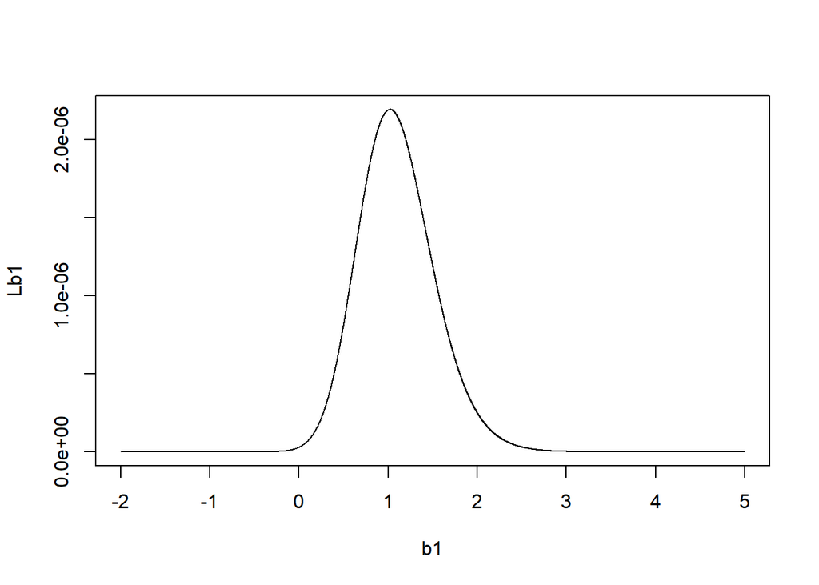

```r
b1=seq(-2,5,length=10000)
p=matrix(0,10000,25)
for (i in 1:length(b1)){
  for (j in 1:length(x)) {
    p[i,j]=exp(b1[i]*x[j])/(1+exp(b1[i]*x[j]))
  }
}
Lb1=matrix(0,10000,1)
Lb2=numeric(10000)
for (i in 1:length(b1)){
  Lb1[i]=prod(p[i,]^y*((1-p[i,])^(1-y))) #likelihood
}

plot(b1,Lb1,type = "l")
```

**(d)** Again, assume $\beta_{0}=0$ and compute $\hat{\beta}_{1}$ using `uniroot()`, a grid search, and by the Newton-Raphson algorithm. You can use the plot in part (c) to find a good initial value.

```r
#uniroot
LB=function(b1){
  sum(x*y-x*exp(b1*x)/(1+exp(b1*x)))
}
uniroot(LB,lower=0.3,upper=2)
```

```
## $root
## [1] 1.022
##
## $f.root
## [1] 0.00004248
##
## $iter
## [1] 6
##
## $init.it
## [1] NA
##
## $estim.prec
## [1] 0.00006104
```

```r
#grid search
#likelihood function
LL=function(b1){
  p=exp(b1*x)/(1+exp(b1*x))
  return(-sum(y*log(p)+(1-y)*log(1-p)))
}
library(NMOF)
#since this function is for searching minimum, I add a negative to the likelihood function to make it valid
gridSearch(LL,lower=0.3,upper=2)$minlevels
```

```
## 1 variables with 5 levels: 5 function evaluations required.
```

```
## [1] 1.15
```

```r
#Newton
b_ini=0.25 #initial valuw
NewtonRaph=function(f,tol=1e-7,x0,N){
  h=1e-7
  i=1
  p=numeric(N)
  while(i <=N){
    dfdx=(f(x0+h)-f(x0))/h
    x1=(x0-(f(x0)/dfdx))
    p[i]=x1
    i=i+1
    if(abs(x1-x0)<tol)break
    x0=x1
  }
  return(p[1:(i-1)])
}
NewtonRaph(LB,x0=b_ini,N=100)
```

```
## [1] 0.8755 1.0125 1.0219 1.0219 1.0219
```

## 8.1

```r
library(RVAideMemoire)
data(chickwts)
x=c(158,171,193,199,230,243,248,248, 250,267,271,316,327,329)
y=c(141,148,169,181,203,213,229, 244,257,260,271,309)

CvM.test(x,y,conf.level=0.95,sim="permutation")
```

```
##
##  Two-sample Cramér-von Mises test
##
## data:  x and y
## T = 30, p-value = 0.4
## alternative hypothesis: two.sided
```

since the p-value is too large, we need to accept the null hypothesis.

## 9.2

```r
f <- function(x, sigma) {
  if (any(x < 0)) return (0)
  stopifnot(sigma > 0)
  return((x / sigma^2) * exp(-x^2 / (2*sigma^2)))
}
m <- 10000
sigma <- 2
x <- numeric(m)
x[1] <- rgamma(1,1,1)
k <- 0
u <- runif(m)
for (i in 2:m) {
  xt <- x[i-1]
  y <- rgamma(1,xt,1)
  num <- f(y, sigma) * dgamma(xt,shape=y, rate=1)
  den <- f(xt, sigma) * dgamma(y, shape=xt, rate=1)
  if (u[i] <= num/den) x[i] <- y else {
    x[i] <- xt
  k <- k+1 #y is rejected
  }
}
print(k) #number of rejected sample
```

```
## [1] 4111
```

```r
k/m #rejected rate
```

```
## [1] 0.4111
```

## 9.4

```r
library(rmutil)
```

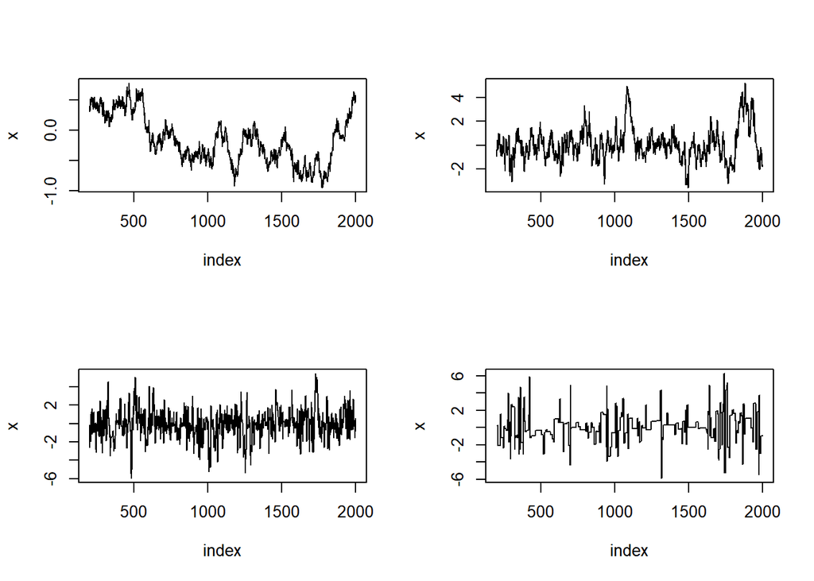

```r
rw.Metropolis=function(sigma,x0,N){
  x=numeric(N)
  x[1]=x0
  u=runif(N)
  k=0 #number of accepted proposals
  for(i in 2:N){
    y=rnorm(1,x[i-1],sigma) #increment?x[i-1]+rnorm(1,0,sigma)
    ratio=dlaplace(y,0,1)/dlaplace(x[i-1],0,1)
    accept=u[i]<=ratio
    x[i]=y*accept+x[i-1]*(1-accept)
    k=k+accept
    }
  return(list(x=x,k=k))
  }

sigma=c(0.05,0.5,2,16)
x0=rlaplace(1,0,1)
N=2000

rw1=rw.Metropolis(sigma[1],x0,N)
rw2=rw.Metropolis(sigma[2],x0,N)
rw3=rw.Metropolis(sigma[3],x0,N)
rw4=rw.Metropolis(sigma[4],x0,N)

index <- 200:2000
par(mfrow=c(2,2))
plot(index, rw1$x[index], type="l", main="", ylab="x")
plot(index, rw2$x[index], type="l", main="", ylab="x")
plot(index, rw3$x[index], type="l", main="", ylab="x")
plot(index, rw4$x[index], type="l", main="", ylab="x")
```

```r
print(c(rw1$k/N,rw2$k/N,rw3$k/N,rw4$k/N)) #acceptance rate
```

```
## [1] 0.9825 0.8345 0.5375 0.1135
```

From the result we can see that when the variance is too small, the rate is high but the chain is not accurate.When sigma=2, the generated chain is the most efficient with the perfect variance

## 9.7

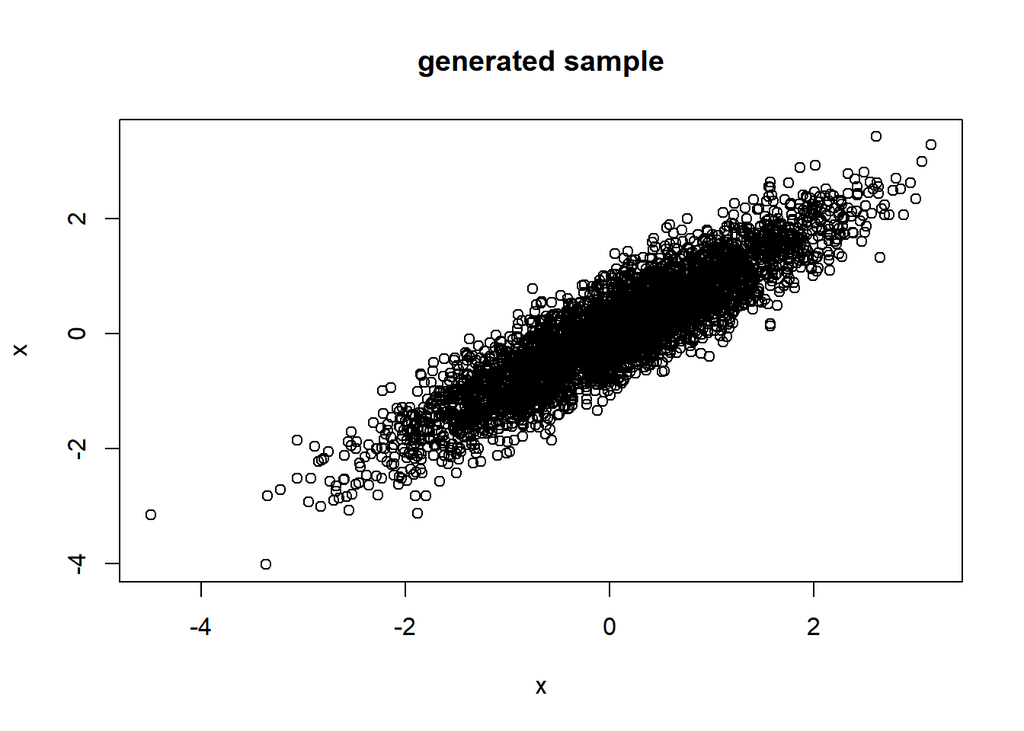

```r
N=5000
X=matrix(0,N,2)
sd1=1
sd2=1
rho=0.9
s1=sqrt(1-rho^2)*sd1
s2=sqrt(1-rho^2)*sd2
X[1,]=c(0,0)
for (i in 2:N){
  y=X[i-1,2]
  m1=0+rho*(y)*sd1/sd2
  X[i,1]=rnorm(1,m1,s1)
  x1=X[i,1]
  m2=0+rho*(x1)*sd2/sd1
  X[i,2]=rnorm(1,m2,s2)
}

#discard burn-in sample
plot(X[1001:5000,],main="generated sample",xlab="x",ylab="x")
```

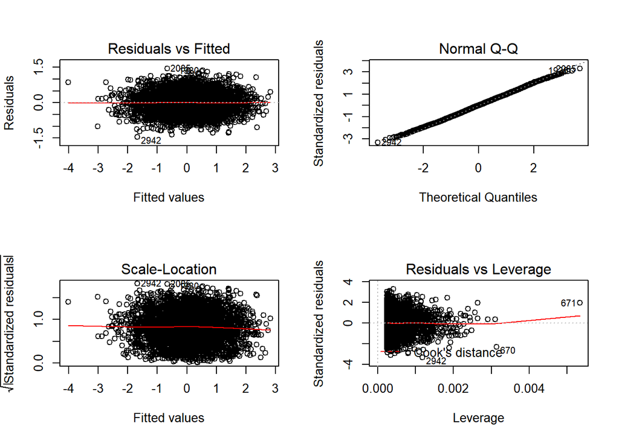

```r
mod=lm(X[1001:5000,2]~X[1001:5000,1])
par(mfrow=c(2,2))
plot(mod)
```

Q-Q plot shows residuals follow normal distribution, and residuals-fitted plot shows constant variance.

## 9.8

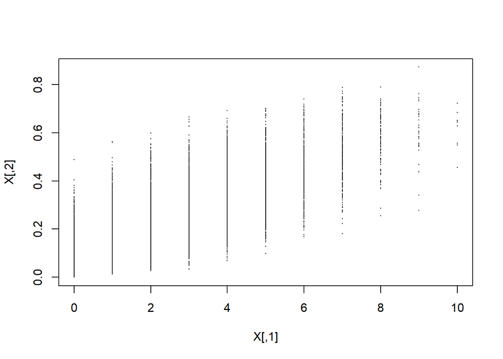

```r
library(stats)
n=10
a=2
b=6
f = function (x, y) {
  # general binomial coefficient
  gamma(n + 1) / (gamma(x + 1) * gamma(n - x + 1))  * y^(x + a - 1) * (1 - y)^(n - x + b - 1)
}
N=10000
X= matrix(0,N,2)
for (i in 2:N){
  y=X[i-1,2]
  X[i,1]=rbinom(1,n,y)
  X[i,2]=rbeta(1,X[i,1]+a,n-X[i,1]+b)
}

plot(X, cex = 0.1)
```

## 9.10

```r
# Rayleigh density f
f <- function(x, sigma) {
  if (any(x < 0)) return (0)
  stopifnot(sigma > 0)
  return((x / sigma^2) * exp(-x^2 / (2*sigma^2)))
  }
#generate chain
chain=function(sigma,m,x1){
  x <- rep(0,m)
  x[1] <- x1
  u <- runif(m)
  for (i in 2:m) {
    xt <- x[i-1]
    y <- rchisq(1, df = xt)
    num <- f(y, sigma) * dchisq(xt, df = y)
    den <- f(xt, sigma) * dchisq(y, df = xt)
    if (u[i] <= num/den) {x[i] <- y}
    else{x[i] <- xt}
    }
    return(x)
}
#Gelman Rubin function
Gelman.Rubin <- function(psi) {
  # psi[i,j] is the statistic psi(X[i,1:j])
  # for chain in i-th row of X
  psi <- as.matrix(psi)
  n <- ncol(psi)
  k <- nrow(psi)
  psi.means <- rowMeans(psi) #row means
  B <- n * var(psi.means) #between variance est.
  psi.w <- apply(psi, 1, "var") #within variances
  W <- mean(psi.w) #within est.
  v.hat <- W*(n-1)/n + (B/n) #upper variance est.
  r.hat <- v.hat / W #G-R statistic
  return(r.hat)
  }
m <- 1000 #length of chain
sigma <- 4  #parmeter of proposal distribution
r.hat=10
while (r.hat>=1.2) {
  k=4
  x0=c(rchisq(k, df=1))
  X=matrix(0,k,m)
  for (i in 1:k){
    X[i,]=chain(sigma,m,x0[i])
  }
  psi=t(apply(X,1,cumsum))
  for (j in 1:nrow(psi)){
    psi[j,]=psi[j,]/(1:ncol(psi))
  }
  r.hat=Gelman.Rubin(psi)
  m=m+1
}
print(m)
```

```
## [1] 1003
```

```r
library(coda)
x1=as.mcmc(X[1,])
x2=as.mcmc(X[2,])
x3=as.mcmc(X[3,])
x4=as.mcmc(X[4,])
mc_X=apply(X, 1,as.mcmc)
combi=mcmc.list(x1,x2,x3,x4)
gelman.diag(combi)
```

```
## Potential scale reduction factors:
##
##      Point est. Upper C.I.
## [1,]       1.01       1.02
```

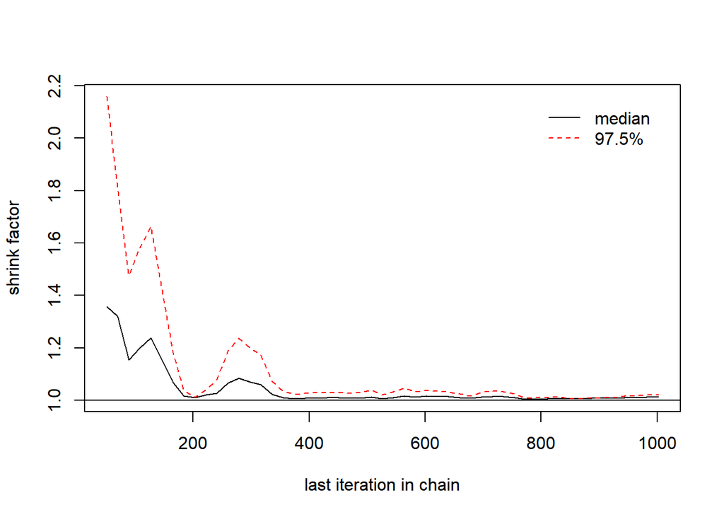

```r
gelman.plot(combi)
```